```python
from IPython.display import display, Image
```

# Thermodynamics of Materials AD19: **Thermodynamics & Statistical Mechanics GRE (Graduate Record Examinations) Exercises**

## compilation by:

### Antonio Osamu Katagiri Tanaka

#### https://www.katagiri-mx.com/

#### GRE Chemistry Subject Test (For Test Takers). (n.d.). Retrieved December 4, 2019, from https://www.ets.org/gre/subject/about/content/chemistry GRE Physics Subject Test (For Test Takers). (n.d.). Retrieved December 4, 2019, from https://www.ets.org/gre/subject/about/content/physics

- An equilibrium state is one in which all bulk physical properties are uniform throughout the system and don’t change with time.
- State functions are functions that take unique values at each equilibrium state.
- Adiathermal = adiabatic = there is no interaction between systems.
- Diathermal = there is a thermal interactions between systems.
- Thermal equilibrium is transitive (i.e. $A \sim B$, $B \sim C$ implies $A \sim C$).
- Thermodynamic equilibrium means thermal equilibrium, mechanical equibrium, and chemical equilibrium.
- Isotherms are surfaces of constant $T$. For an ideal gas $$ P V = n R T $$, so isotherms are hyperbolas.
- A quasistatic process is one that passes through a series of equilibrium states.
- Reversible processes are quasistaic processes for which no dissipative forces like friction are present.
- Bulk modulus: $$ K \equiv -V \left(\frac{\partial P}{\partial V}\right)_T $$
- Volume thermal expansivity: $$ \beta \equiv \frac{1}{V} \left(\frac{\partial V}{\partial T}\right)_P $$
- Linear expansion coefficient: $$ \alpha \equiv \frac{1}{L} \left(\frac{\partial L}{\partial T}\right)_F $$, where $F$ is the tension. In general, $$ \beta = 3 \alpha $$
- Young's modulus: $$ Y \equiv \frac{L}{A} \left(\frac{\partial F}{\partial L}\right)_T $$
- Compressibility: $$ \kappa = \frac{1}{K} $$
- Force is related to pressure and area by $F = P dA$, so $$ dW = -P dV $$ for a reversible process. Thus, the total work done on a system is $$ W = - \int_{V_1}^{V_2} P dV $$
- The adiabatic free expansion is not reversible, and there is no work done on the system and no change in entropy. For a wire: $$ dW = F dx $$
- The first law of thermodynamics: $$ \Delta U = W + Q $$, where $U$ is the internal energy of the system, $W$ is the work done on the system, and $Q$ is the heat added to the system. For a reversible process, $$ dU = dQ - P dV $$
- Adiabatic Process During an adiabatic process, the system is insulated such that there is no heat transfer between the system and its environment. Thus $$ dQ = 0 $$, so $$ \Delta E_{int} = −W $$ If work is done on the system, negative $W$, then there is an increase in its internal energy. Conversely, if work is done by the system, positive $W$, there is a decrease in the internal energy of the system.
- Constant Volume (Isochoric) Process, If the volume is held constant, then the system can do no work, $$ dW = 0 $$, thus $$ \Delta E_{int} = Q $$ If heat is added to the system, the temperature increases. Conversely, if heat is removed from the system the temperature decreases
- Closed Cycle In this situation, after certain interchanges of heat and work, the system comes back to its initial state. So $\Delta E_{int}$ remains the same, thus $$ \Delta Q = \Delta W $$ The work done by the system is equal to the heat or energy put into it.
- For a free expansion, $$ \Delta W = 0 $$ $$ \Delta E_{int} = 0 $$ $$ \Delta Q = 0 $$ In this process, no work is done on or by the system.
- The heat capacity: $$ C = \lim_{\Delta T \rightarrow 0} \frac{Q}{\Delta T} = \frac{dQ}{dT} $$ $$ Q = C (T_f - T_i) $$
- The specific heat $c = C/m$.
- $C_V$ is the heat capacity at constant volume, $$ C_V = \frac{dQ_V}{dT} = \left(\frac{\partial U}{\partial T}\right)_V $$
- $C_P$ is the heat capacity at constant pressure, $$ C_P = \frac{dQ_P}{dT} = \left(\frac{\partial H}{\partial T}\right)_P $$, where $H = U + PV$ is the enthalpy.
- $\gamma$ is defined by, $$ \gamma = \frac{C_P}{C_V} > 1 $$
- For an ideal gas, $$ C_P = C_V + R $$ $$ Q = n C_V \Delta T $$

| Molecule | $$ C_V $$ | $$ \gamma $$ |
| --- | --- | --- |
| Monotomic | $$ \frac{3}{2} R $$ | $$ \frac{5}{3} $$ |
| Diatomic | $$ \frac{5}{2} R $$ | $$ \frac{7}{5} $$ |
| Plyatomic | $$ 3 R $$ | $$ \frac{4}{3} $$ |

- For a monotomic ideal gas, $$ U = \frac{3}{2} n R T $$ $$ C_V = \frac{3}{2} n R $$ $$ \gamma = \frac{5}{3} $$
- For an ideal gas, $$ U = U(T) $$ is a function of temperature only. In reality, all gases cool slightly during expansion, due to intermolecular attraction potential energy increasing with expansion.
- For an adiabatic, $$ P V^{\gamma} = constant $$ $$ T V^{\gamma - 1} = constant $$
- For a Van der Waals gas, $$ \left(P + \frac{a}{v^2}(V - n b) = n R T\right) $$, where $a$ and $b$ are constants and $v = V/n$ is the molar volume

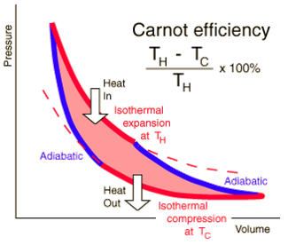

```python
display(Image(filename='./img/carnotEfficiency.png'))
```

- In the Carnot cycle, the top and bottom curves are isotherms in which heat enters at temperature $T_H$ and exits at temperature $T_C$, respectively.
- The side curves are adiabats.
- The work done is the area bounded by the four curves.
- The efficiency os the engine: $$ \eta = \frac{W}{Q_H} = 1 - \frac{Q_C}{Q_H} = 1 - \frac{T_C}{T_H} $$
- The second law of thermodynamics says that 100% efficiency is impossible. More precisely, it is impossible to construct a device that, operating in a cycle, will produce no effect other than the extraction of heat from a single body at uniform temperature and perform an equivalent amount of work. Carnot’s theorem says that the Carnot engine is the most efficient engine between any two reservoirs.
- The heat entering in an isotherm is, $$ Q = n R T ln\left(\frac{V_{end}}{V_{start}}\right) $$
- Running the Carnot cycle backward gives a refrigerator with efficiency, $$ \eta_R = \frac{Q_C}{W} = \frac{Q_C}{Q_H - Q_C} = \frac{T_C}{T_H - T_C} $$
- The efficiency of a heat pump is, $$ \eta_H = \frac{Q_H}{W} = \frac{Q_H}{Q_H - Q_C} = \frac{T_H}{T_H - T_C} $$
- The Clausius equation: $$ \oint \frac{dQ}{T_0} \leq 0 $$, where $T_0$ is the temperature of the auxiliary reservoir, and equality holds if and only if the cycle is reversible.
- Change in entropy is defined by, $$ \Delta S \equiv \int_i^f \frac{dQ_R}{T} $$, where the path is reversible.
- For any reversible process, $$ dQ_R = T dS $$
- For an isothermal free expansion, $$ \Delta S = n R ln \left(\frac{V_f}{V_i}\right) $$
- In general, $$ \frac{dQ}{T} \leq dS $$, and equality holds if and only if the process is reversible.
- For a thermally isolated system, $$ \Delta S \geq 0 $$, with equality holding if and only if the process is reversible.
- The central equation of thermodynamics: $$ T dS = dU + P dV $$, which holds for a reversible process.
- For an ideal gas, of molar entropy $s$, $$ s = C_V ln T + R ln v + s_0 $$
- In general, $$ S = k_B ln \Omega $$, where $k_B$ is Boltzmann’s constant and $\Omega$ is the thermodynamic probability, or the number of microstates giving rise to this macrostate.
- The specific heat capacity in terms of the entropy is, $$ C_V = T \left(\frac{\partial S}{\partial T}\right)_V $$ $$ C_P = T \left(\frac{\partial S}{\partial T}\right)_P $$
- The Helmholtz function: $$ F = U - T S $$ For a process in which the end point temperatures are the same as the surroundings, the maximum work obtainable equals the decrease in F. F at a minimum is the condition for thermodynamic equilibrium for a system held at constant volume.
- Gibbs function: $$ G = H - T S $$ G at a minimum is the condition for thermodynamic equilibrium for a system in contact with a heat and pressure reservoir.
- For a chemical reaction at temperature T0, $$ \Delta H - T_0 \Delta S \leq 0 $$
- Maxwell’s relations: $$ \left(\frac{\partial V}{\partial S}\right)_P = \left(\frac{\partial T}{\partial P}\right)_S $$ $$ \left(\frac{\partial S}{\partial V}\right)_T = \left(\frac{\partial P}{\partial T}\right)_V $$ $$ -\left(\frac{\partial S}{\partial P}\right)_T = \left(\frac{\partial V}{\partial T}\right)_P $$ $$ -\left(\frac{\partial T}{\partial V}\right)_S = \left(\frac{\partial P}{\partial S}\right)_V $$ These can be remembered by going around the wheel twice in opposite directions from different starting points, $$ \begin{array}{ccc}
  - & S & \ P & & V \ & T & \ \end{array} $$

## GR0177

### 5. A three-dimensional harmonic oscillator is in thermal equilibrium with a temperature reservoir at temperature T. The average total energy of the oscillator is

(A) $$ \frac{1}{2} k T $$

(B) $$ k T $$

(C) $$ \frac{3}{2} k T $$

(D) $$ 3 k T $$

(E) $$ 6 k T $$

- Each degree of freedom contributes roughly $k T$ to the average total energy.
- There are 3 translational degrees of freedom, 3 vibrational degrees of freedom and 3 rotational degrees of freedom.
- The total energy is $9 k T$. Divide that by the number of dimensions to get $3 k T$.

### 6. An ideal monatomic gas expands quasi-statically to twice its volume. If the process is isothermal, the work done by the gas is $W_i$. If the process is adiabatic, the work done by the gas is $W_a$. Which of the following is true?

(A) $$ W_i = W_a $$

(B) $$ 0 = W_i < W_a $$

(C) $$ 0 < W_i < W_a $$

(D) $$ 0 = W_a < W_i $$

(E) $$ 0 < W_a < W_i $$

- The work done by an adiabatic process is $$ W = \frac{1}{\gamma - 1} (P_2 V_2 - P_1 V_1) $$
- One can quickly derive this from noting that $$ P V^\gamma = const $$ in an adiabatic process and $$ W = \int P dV $$
- The work done by an isothermal process is $$ W = n R T_i ln\left(\frac{V_2}{V_1}\right) = P_i V_i ln\left(\frac{V_2}{V_1}\right) $$
- One can quickly derive this from noting that $$ P_1 V_1 = P_2 V_2 = n R T_1 = n R T_2 $$ for an isothermal process
- From the above formulae, one can immediately eliminate choice (A).
- One can calculate the isothermal work to be $$ W_i = n R T_1 ln2 = P_1 V_1 ln2 $$
- One can calculate the adiabatic work to be: $$ Wa = \frac{1}{1 − \gamma} (P_1 − 2 P_2) V_1 = \frac{1}{1 − \gamma} (P_1 − \frac{2}{2^\gamma} P_1)V_1 = \frac{1}{1 − \gamma} (1 − 2^{1 − \gamma}) P_1 V_1 $$
- For a monatomic gas, $$ \gamma = \frac{5}{3} $$, and one finds that $$ 0 < W_a < W_i $$. Choice (E).
- Also, in general, an adiabatic process always does less work than an isothermal process in a closed cycle.

### 35. If the absolute temperature of a blackbody is increased by a factor of 3, the energy radiated per second per unit area does which of the following?

(A) Decreases by a factor of 81.

(B) Decreases by a factor of 9.

(C) Increases by a factor of 9.

(D) Increases by a factor of 27.

(E) Increases by a factor of 81.

- The blackbody radiation formula has $$ u = \sigma T^4 $$. The ratio of energy radiated is thus $$ \frac{{T_2}^4}{{T_1}^4} $$. Since $$ T_2 = 3 T_1 $$, the ratio is just $$ 3^4 = 81 $$, as in choice (E). (Obviously an increase since the final temperature is much higher than the initial.)

### 36. Consider the quasi-static adiabatic expansion of an ideal gas from an initial state $i$ to a final state $f$. Which of the following statements is NOT true?

(A) No heat flows into or out of the gas.

(B) The entropy of state $i$ equals the entropy of state $f$.

(C) The change of internal energy of the gas is $$ - \int P dV $$

(D) The mechanical work done by the gas is $$ \int P dV $$

(E) The temperature of the gas remains constant.

- In an adiabatic expansion, $dS = 0$ (entropy), since $dQ = 0$ (heat).
- No heat flows out, by definition, and thus choice (A) is out, as well as choice (B).
- Choice (C) is true since by the first law, one has $Q = U + W \Rightarrow U = −W$, and the given integral is just the definition of work.
- Choice (D) defines work.
- Choice (E) remains—so take that.

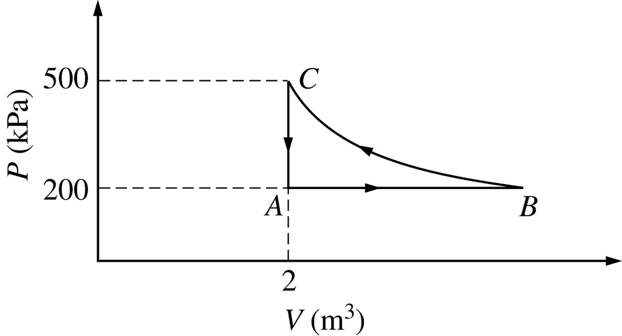

```python
display(Image(filename='./img/GR0177_37.png'))
```

### 37. A constant amount of an ideal gas undergoes the cyclic process $ABCA$ in the $PV$ diagram shown above. The path $BC$ is isothermal. The work done by the gas during one complete cycle, beginning and ending at $A$, is most nearly

(A) $600 kJ$

(B) $300 kJ$

(C) $0$

(D) $-300 kJ$

(E) $-600 kJ$

- For path $C$ to $A$, one has $W = 0$ for an isochoric (constant volume) process.
- For path $A$ to $B$, one has just $W = P \Delta V = 200(V_B − 2)$ for an isobaric (constant pressure) process.
- For path $B$ to $C$, one has $$ W = P_c V_c ln \frac{V_C}{V_B} = 1000 ln \frac{2}{V_b} $$
- One can figure out $V_B$ from the isothermal condition $$ P_C V_C = P_B V_B \rightarrow V_B = \frac{P_C}{P_B} V_C = \frac{5}{2} \times 2 = 5 $$. Plug that in above to get, $$ W_{CA} = 0 $$ $$ W_{AB} = 600 $$ $$ W_{BC} = 1000 ln \frac{2}{5} > −1000 $$ $$ W \approx −400 $$, which is closest to choice (D).

### 47. A sealed and thermally insulated container of total volume $V$ is divided into two equal volumes by an impermeable wall. The left half of the container is initially occupied by $n$ moles of an ideal gas at temperature $T$. Which of the following gives the change in entropy of the system when the wall is suddenly removed and the gas expands to fill the entire volume?

(A) $2 n R ln2$

(B) $n R ln2$

(C) $\frac{1}{2} n R ln2$

(D) $- n R ln2$

(E) $- 2 n R ln2$

- Entropy is given as $$ dS = \int \frac{dQ}{T} $$. Since the volume expands by a factor of 2, the work in the isothermal process is $$ W = n R T ln \frac{V_2}{V_1} = n R T ln2 $$. But, for an ideal gas, the internal energy change in an isothermal process is $0$, thus from the first law of Thermodynamics, one has $$ dQ = dW + dU \Rightarrow dQ = dW $$. The temperature cancels out in the entropy integral, and thus the entropy is just $$ n R ln2 $$, as in choice (B).

### 48. A gaseous mixture of $O_2$ (molecular mass $32 u$) and $N_2$ (molecular mass $28 u$) is maintained at constant temperature. What is the ratio $$ \frac{\nu_{rms}(N_2)}{\nu_{rms}(O_2)} $$ of the root-mean-square speeds of the molecules?

(A) $$ \frac{7}{8} $$

(B) $$ \sqrt{\frac{7}{8}} $$

(C) $$ \sqrt{\frac{8}{7}} $$

(D) $$ \left(\frac{8}{7}\right)^2 $$

(E) $$ ln\left(\frac{8}{7}\right) $$

- In case one forgets the $RMS$ speed, one does not need to go through the formalism of deriving it with the Maxwell-Boltzmann distribution.
- Instead, one can approximate its dependence on mass and temperature by $$ \frac{3}{2} k T = \frac{1}{2} m v^2 $$. One thus has $$ v \propto \sqrt{\frac{k T}{m}} $$
- For the ratio of velocities, one has $$ \frac{v_N}{v_O} = \frac{m_O}{m_N} $$
- Plug in the given molecular masses for Oxygen and Nitrogen to get choice (C).

### 49. In a Maxwell-Boltzmann system with two states of energies $\epsilon$ and $2 \epsilon$, respectively, and a degeneracy of $2$ for each state, the partition function is

(A) $$ e^{- \frac{\epsilon}{k T}} $$

(B) $$ 2 e^{- \frac{2 \epsilon}{k T}} $$

(C) $$ 2 e^{- \frac{3 \epsilon}{k T}} $$

(D) $$ e^{- \frac{\epsilon}{k T}} + e^{- \frac{2 \epsilon}{k T}} $$

(E) $$ 2 \left[ e^{- \frac{\epsilon}{k T}} + e^{- \frac{2 \epsilon}{k T}} \right] $$

- The partition function is given by the formula $$ Z = {\sum}_i g_i e^{- \frac{\epsilon_i}{k T}} $$, where $g_i$ enotes the degeneracy of the ith state.
- Plug in the given information into the formula to get choice (E).

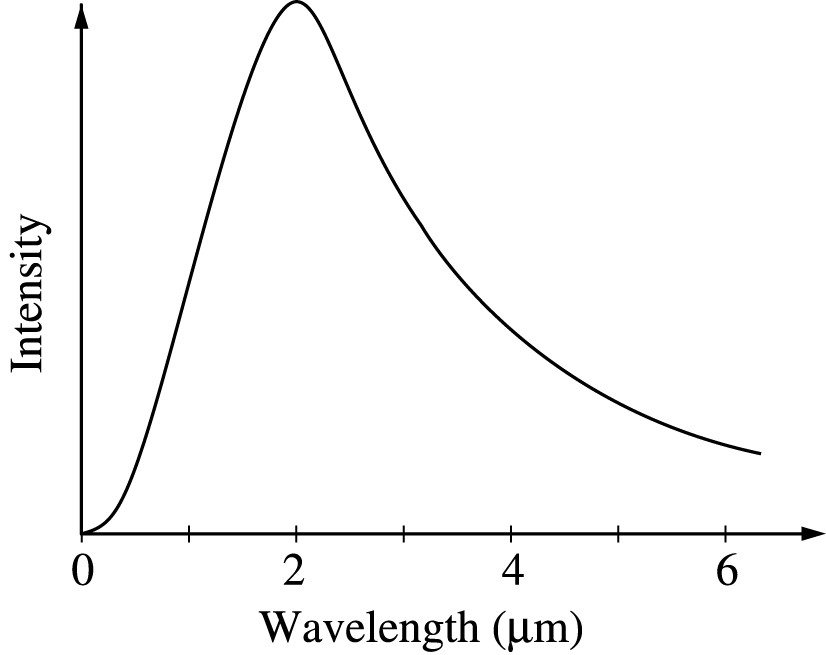

```python
display(Image(filename='./img/GR0177_63.png'))
```

### 63. The distribution of relative intensity $I(\lambda)$ of blackbody radiation from a solid object versus the wavelength $\lambda$ is shown in the figure above. If the Wien displacement law constant is $2.9 \times 10^{-3} m \cdot K$, what is the approximate temperature of the object?

(A) $10 K$

(B) $50 K$

(C) $250 K$

(D) $1,500 K$

(E) $6,250 K$

- Recall Wien’s Law, $$ \lambda T = 2.9 \times 10^{−3} $$. It relates the temperature with the wavelength at maximal intensity.
- The wavelength at the maximal intensity is approximately $2 \mu m$. Plugging this in, one finds that $$ T = \frac{2.9 \times 10^{−3}}{2 \times 10^{−6}} \approx 1500K $$, as in choice (D).

### $$ C = 3 k N_A \left(\frac{h \nu}{k T}\right)^2 \frac{e^{\frac{h \nu}{k T}}}{\left(e^{\frac{h \nu}{k T}} - 1\right)^2} $$

### 65. Einstein’s formula for the molar heat capacity $C$ of solids is given above. At high temperatures, $C$ approaches which of the following?

(A) $$ 0 $$

(B) $$ 3 k N_A \frac{h \nu}{k T} $$

(C) $$ 3 k N_A h \nu $$

(D) $$ 3 k N_A $$

(E) $$ N_A h \nu $$

- At high temperatures, one has $k T \gg h \nu$.
- One expands the argument of the denominator according to $e^x \approx 1 + x$ (for small $x$). The denominator becomes $\left(1 + \frac{h \nu}{k T} − 1\right) = \frac{h \nu}{k T}$. Since the whole quantity of the denominator is squared, the top $\left(\frac{h \nu}{k T}\right)^2$ term is canceled.
- In the numerator, one has $e^{\frac{h \nu}{k T}} \rightarrow 1$, since $e^{\frac{1}{\infty}} \rightarrow e^0 \rightarrow 1$.
- Thus, one arrives at choice (D).
- One either remembers this fact about solid or one derives it, as shown above. (Also, for low temperatures, at say around $20K$ for most solids, the Debye $T^3$ law applies, and specific heat is proportional to $T^3$. Debye’s theory is more accurate for solids.

### 77. An ensemble of systems is in thermal equilibrium with a reservoir for which $k T = 0.025 eV$. State $A$ has an energy that is $0.1 eV$ above that of state $B$. If it is assumed the systems obey Maxwell-Boltzmann statistics and that the degeneracies of the two states are the same, then the ratio of the number of systems in state $A$ to the number in state $B$ is

(A) $e^{+4}$

(B) $e^{+0.25}$

(C) $1$

(D) $e^{-0.25}$

(E) $e^{-4}$

- The Maxwell-Boltzmann distribution is $N \propto g e^{−\epsilon/(kT)}$ , where $g$ is the degeneracy.
- Given $\epsilon_a = 0.1 + \epsilon_b$, one finds the ratio of distributions (thus ratio of numbers) to be $$ \frac{e^{− \frac{(0.1+\epsilon_b)}{k T}}}{e^{− \frac{\epsilon_b}{k T}}} = e^{− \frac{0.1}{k T}} $$
- The problem gives $kT = 0.025 eV$, and thus the above ratio becomes $$ e^{−.1/.025} = e^{−4} $$, as in choice(E).

## GR0627

### $$ C_{(s)} + {CO_2}_{(g)} \rightleftharpoons 2 CO_{(g)} $$

### 7. $\Delta H$ for the reaction shown above is greater than zero. Assuming $\Delta H$ is independent of temperature, which of the following statements about the percent yield of $CO_{(g)}$ is true?

(A) It increases as the amount of $C_{(s)}$ increases.

(B) It increases as the temperature increases.

(C) It decreases as the temperature increases.

(D) It doubles when the initial partial pressure of $CO_2$ is doubled.

(E) It increases when the total pressure of the reaction system increases.

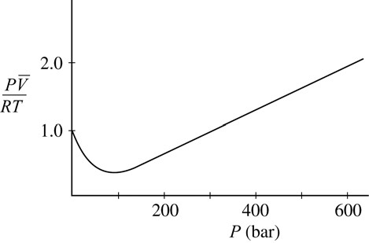

```python
display(Image(filename='./img/GR0627_16.png'))
```

### 16. The curve shown above illustrates the $P \bar{V}$ behavior of a real gas, where $\bar{V}$ is the molar volume. According to the van der Waals model for nonideal gas behavior, the values of $\frac{P \bar{V}}{R T}$ greater than 1.0 at high pressures are due to

(A) the effects of increased rate of collision of the molecules with the walls of the container

(B) the effects of dissociation of individual gas molecules

(C) the effects of the volume occupied by the molecules themselves

(D) the effects of forces of attraction between molecules

(E) ideal gas behavior in this pressure region

### $$ {O_3}_{(g)} \rightarrow \frac{3}{2} {O_2}_{(g)} $$

### 17. For the reaction shown above at $298 K$, $\Delta G^{\circ} = -163 kJ/mol$. What is the value of the equilibrium constant, $K_P$, for this reaction?

(A) $K_P > 1.0$

(B) $K_P = 1.0$

(C) $0.0 < K_P < 1.0$

(D) $K_P = 0.0$

(E) $K_P < 0.0$

### 25. When $1.0 kJ$ of heat is added to $5.0 L$ of an ideal gas, the gas expands against a constant external pressure of $1.0 bar$ to a final volume of $8.0 L$. What is the change in internal energy, $\Delta U$, for the gas? ($1.0 L \cdot bar = 0.10 kJ$)

(A) $0.30 kJ$

(B) $0.70 kJ$

(C) $1.0 kJ$

(D) $1.3 kJ$

(E) $1.8 kJ$

### 26. Which of the following must be true for adiabatic processes?

(A) $C_V = C_P$

(B) $\Delta H = 0$

(C) $\Delta U = 0$

(D) $\Delta S = 0$

(E) $q = 0$

### 33. Two cylinders, one containing $1 mole$ of $C_4H_{10}$ gas at $1 atm$ and the other containing $1 mole$ of $CH_4$ gas at $1 atm$, are at $288 K$. If each gas absorbs $100 J$ of heat under conditions of constant volume, which of the following is true?

(A) The temperature of the $CH_4$ increases more than the temperature of the $C_4H_{10}$.

(B) The internal energy of both the $CH_4$ and the $C_4H_{10}$ decreases.

(C) The heat capacity of the $C_4H_{10}$ is less than the heat capacity of the $CH_4$.

(D) The entropy of both the $CH_4$ and the $C_4H_{10}$ decreases.

(E) The heat transferred to the $C_4H_{10}$ is greater than the heat transferred to the $CH_4$.

### 34. Which of the following statements is true about a pure substance above its critical point?

(A) One fluid phase is present.

(B) Solid, liquid, and gas are in equilibrium.

(C) Only liquid and gas are in equilibrium.

(D) A liquid forms.

(E) A solid forms.

### 37. At standard temperature and pressure, all of the following compounds exist in the gas state EXCEPT

(A) $H Cl$

(B) $H Br$

(C) $N H_3$

(D) $B H_3$

(E) $Li H$

### 49. For a system at thermal equilibrium, which of the following is the Boltzmann distribution expression for the probability, $p_i$, that a single molecule is in the $ith$ energy state with energy $\varepsilon_i$ ?

(A) $$ p_i = \frac{\varepsilon_i}{k T} $$

(B) $$ p_i = 1 - e^{-\frac{\varepsilon_i}{k T}} $$

(C) $$ p_i = \left(\sum_{i = 0}^{\infty} e^{-\frac{\varepsilon_i}{k T}}\right) - e^{-\frac{\varepsilon_i}{k T}} $$

(D) $$ p_i = \left(e^{-\frac{\varepsilon_i}{k T}}\right)^{N_i} $$

(E) $$ p_i = \frac{e^{-\frac{\varepsilon_i}{k T}}}{\left(\sum_{i = 0}^{\infty} e^{-\frac{\varepsilon_i}{k T}}\right)} $$

### 50. Which of the following expressions involving fugacity, $f$, is correct as $P \rightarrow 0$ ?

(A) $f = P$

(B) $f = \frac{1}{P}$

(C) $f = 1$

(D) $f = \frac{1}{V}$

(E) $f = V$

### 51. Sodium acetate spontaneously crystallizes out of a supersaturated solution on standing or on the addition of a seed crystal. Which of the following is true for the thermodynamic quantities of this system for this process?

(A) $\Delta S < 0, \Delta H < 0$

(B) $\Delta S < 0, \Delta G > 0$

(C) $\Delta S > 0, \Delta H > 0$

(D) $\Delta S > 0, \Delta G < 0$

(E) $\Delta G < 0, \Delta H > 0$

### 52. If ideal gas behavior is assumed, for which of the following reactions does $\Delta H$ equal $\Delta U$ ?

(A) $N_2{O_4}_{(g)} \rightarrow 2 N{O_2}_{(g)}$

(B) $C{H_4}_{(g)} + 2 {O_2}_{(g)} \rightarrow C{O_2}_{(g)} + 2 H_2O_{(l)}$

(C) $S{O_2}_{(g)} + \frac{1}{2}{O_2}_{(g)} \rightarrow S{O_3}_{(g)}$

(D) ${Br_2}_{(l)} + 3 {Cl_2}_{(g)} \rightarrow 2 Br{Cl_3}_{(g)}$

(E) ${Cl_2}_{(g)} + {F_2}_{(g)} \rightarrow 2 ClF_{(g)}$

### $$ \left(\frac{\partial U}{\partial V}\right)_T = - P + T \left(\frac{\partial P}{\partial T}\right)_V $$

### 58. Given the expression above, what is the value of $$ \left(\frac{\partial U}{\partial V}\right)_T $$ for an ideal gas undergoing isothermal expansion? ($P V = n R T$ for an ideal gas.)

(A) $-P + \frac{n R}{V}$

(B) $nR$

(C) $-P$

(D) $1$

(E) $0$

### 59. The heat of fusion of ice is $333.5 J/g$. The entropy change for the water when freezing $5.0 g$ of water at $0^{\circ}C$ and $1 atm$ pressure is

(A) $6.1 J/K$

(B) $1.2 J/K$

(C) $0$

(D) $-1.2 J/K$

(E) $-6.1 J/K$

### 104. A large activation energy implies which of the following about a reaction?

(A) It is spontaneous.

(B) It is highly endothermic.

(C) It is at equilibrium.

(D) It is very rapid.

(E) It has a highly temperature-dependent rate constant.

## GR0877

### 8. The energy from electromagnetic waves in equilibrium in a cavity is used to melt ice. If the Kelvin temperature of the cavity is increased by a factor of two, the mass of ice that can be melted in a fixed amount of time is increased by a factor of

(A) 2

(B) 4

(C) 8

(D) 16

(E) 32

- Power = Work / time
- Stefan-Boltzmann Law: $$ P_1 = A \varepsilon \sigma T^4 $$
- So twice the temperature in same amount of time: $$ P_2 = A \varepsilon \sigma (2 T)^4 = 16 A \varepsilon \sigma T^4 = 16 P_1 $$

### 21. For an adiabatic process involving an ideal gas having volume $V$ and temperature $T$, which of the following is constant? $\left(\gamma = \frac{C_P}{C_V}\right)$

(A) $T V$

(B) $T V^\gamma$

(C) $T V^{\gamma - 1}$

(D) $T^\gamma V$

(E) $T^\gamma V^{-1}$

- Adiabatic process means no heat exchanged, all energy is transfered as work.
- for adiabatic process: $$ P V^{\gamma} = constant $$ $$ \gamma = \frac{C_P}{C_V} $$, where $C_P$ is specific heat for constant pressure and $C_V$ is specific heat for constnat volume
- Ideal Gas Law: $$ P V = n k T $$ $$ P = n k (T V^{-1}) $$ $$ n k (T V^{-1}) V^{\gamma} = constnat $$ $$ T V^{-1} V^{\gamma} = P V^{\gamma} = constant $$

### 33. A thermodynamic system, initially at absolute temperature $T_1$ , contains a mass $m$ of water with specific heat capacity $c$. Heat is added until the temperature rises to $T_2$ . The change in entropy of the water is

(A) $$ 0 $$

(B) $$ T_2 - T_1 $$

(C) $$ m c T_2 $$

(D) $$ m c (T_2 - T_1) $$

(E) $$ m c ln \left(\frac{T_2}{T_1}\right) $$

- 2nd Law of Thermodynamics $$ dS = \frac{dQ}{T} $$ $$ \Delta Q = c m \Delta T $$ $$ dQ = c m \Delta T $$, $c$ is the specific heat capacity

$$ dS = c m \frac{dT}{T} $$$$ \int dS = \Delta S $$

if integrated from $T = T_1$ to $T = T_2$ $$ \int dS = cm \int \frac{dT}{T} = c m ln \frac{T_2}{T_1} $$

### 34. Heat $Q$ is added to a monatomic ideal gas under conditions of constant volume, resulting in a temperature change $\Delta T$. How much heat will be required to produce the same temperature change, if it is added under conditions of constant pressure?

(A) $$ \frac{3}{5} Q $$

(B) $$ Q $$

(C) $$ \frac{5}{3} Q $$

(D) $$ 2 Q $$

(E) $$ \frac{10}{3} Q $$

- Fundamental equation of Thermodynamics $$ dU = T dS - P dV $$
- Constant volume yields $$ dU_1 = T dS = dQ_1 = 1.5 R dT $$
- Constant pressure yields $$ dU_2 = 1.5 R dT - P dV $$
- ideal gas law with $n = 1$ $$ P V = R T $$ $$ V = \frac{RT}{P} $$

$$ dU_2 = dQ_2 - P dV = dQ_2 - R dT $$$$ dQ_2 = dU_2 + R dT $$$$ dQ_2 = dU_1 + R dT $$

(same temperature range) $$ dQ_2 = 1.5 R dT + R dT = 2.5 R dT $$

$$ \frac{dQ_2}{dQ_1} = \frac{2.5 R dT}{1.5 R dT} = \frac{5}{3} R dT = \frac{5}{3} Q $$

### 35. A heat pump is to extract heat from an outdoor environment at $7^{\circ} C$ and heat the environment indoors to $27^{\circ} C$. For each $15,000 J$ of heat delivered indoors, the smallest amount of work that must be supplied to the heat pump is approximately

(A) $500 J$

(B) $1,000 J$

(C) $1,100 J$

(D) $2,000 J$

(E) $2,200 J$

- Carnot Engine Efficiency $$ 1 - \frac{T_C}{T_H} = \frac{W}{Q} $$ $$ W = Q_H \left(1 - \frac{T_C}{T_H}\right) $$ $$ W = 15000 J \left(1 - \frac{280 K}{300 K}\right) = 1000 J $$

### $$ \left(p + \frac{a}{V^2}\right) (V - b) = R T $$

### 79. Consider $1 mole$ of a real gas that obeys the van der Waals equation of state shown above. If the gas undergoes an isothermal expansion at temperature $T_0$ from volume $V_1$ to volume $V_2$, which of the following gives the work done by the gas?

(A) $$ 0 $$

(B) $$ R T_0 ln \left(\frac{V_2}{V_1}\right) $$

(C) $$ R T_0 ln \left(\frac{V_2 - b}{V_1 - b}\right) $$

(D) $$ R T_0 ln \left(\frac{V_2 - b}{V_1 - b}\right) + a \left(\frac{1}{V_2} - \frac{1}{V_1}\right) $$

(E) $$ R T_0 \left(\frac{1}{(V_2 - b)^2} - \frac{1}{(V_2 - b)^2}\right) + a \left(\frac{1}{{V_2}^3} - \frac{1}{{V_1}^3}\right) $$

- For ideal gas $$ P = \frac{n R T}{V} $$
- Work $$ W = n R T \int \frac{dT}{T} = n R T ln \frac{V_f}{V_i} $$
- But for real gas: $$ P = \frac{R T}{V - b} - \frac{a}{V^2} $$

$$ W = R T \int \frac{dV}{V - b} - \left(a \int \frac{dV}{V^2}\right) $$$$ W = R T ln \frac{V_2 - b}{V_1 - b} - a \left(\frac{1}{-V_2} - \frac{1}{-V_1}\right)$$

## GR1727

### $$ \left(P + \frac{a n^2}{V^2}\right) (V - n b) = n R T $$

### 6. Of the following substances, which is likely to have the largest value of the coefficient $a$ in the van der Waals equation of state for real gases shown above?

(A) $H_2$

(B) $N_2$

(C) $CH_4$

(D) $NH_3$

(E) $CO_2$

### 15. Which of the following must be true about a binary liquid mixture that obeys Raoult’s law?

### I. The partial pressure of each component at equilibrium is proportional to its mole fraction in the liquid mixture.

### II. The volume of the mixture is equal to the sum of the volumes of each component before mixing.

### III. Intermolecular interactions in the mixture are identical to intermolecular interactions in the pure components.

(A) I only

(B) III only

(C) I and III only

(D) II and III only

(E) I, II, and III

### 21. Which of the following is always true of a spontaneous process?

(A) The process is exothermic.

(B) The process does not involve any work.

(C) The entropy of the system increases.

(D) The internal energy of the system decreases.

(E) The total entropy of the system plus surroundings increases.

### 22. The equation $\Delta H = \Delta U + P \Delta V$ is applicable

(A) always

(B) only for constant pressure processes

(C) only for constant temperature processes

(D) only for constant volume processes

(E) only for constant entropy processes

### 23. A system that consists of a sample of nitrogen gas behaving as an ideal gas is compressed at a constant temperature. Which of the following is true about $w$ (work) and $q$ (heat transfer) for this process?

(A) $w > 0$; $q < 0$

(B) $w > 0$; $q > 0$

(C) $w < 0$; $q < 0$

(D) $w < 0$; $q > 0$

(E) $w = 0$; $q = 0$

### 24. What is the maximum number of phases that can be at equilibrium with each other in a three-component mixture?

(A) 2

(B) 3

(C) 4

(D) 5

(E) 6

### 27. The dissociation energy for a hydrogen-bromine bond is defined as the change in enthalpy, $\Delta H$, for which of the following reactions?

(A) $2 HBr_{(g)} → {H_2}_{(g)} + {Br_2}_{(l)}$

(B) $HBr_{(g)} → {H^+}_{(g)} + {Br^−}_{(g)}$

(C) $H_{(g)} + Br_{(g)} → HBr_{(g)}$

(D) ${H_2}_{(g)} + {Br_2}_{(l)} → 2 HBr_{(g)}$

(E) $HBr_{(g)} → H_{(g)} + Br_{(g)}$

### 37. Of the following compounds, which has the lowest melting point?

(A) $HCl$

(B) $AgCl$

(C) $CaCl_2$

(D) $CCl_4$

(E) $SnCl_4$

(A) $\Delta H = 0$; $\Delta S = 0$

(B) $\Delta H > 0$; $\Delta S > 0$

(C) $\Delta H > 0$; $\Delta S < 0$

(D) $\Delta H < 0$; $\Delta S > 0$

(E) $\Delta H < 0$; $\Delta S < 0$

### $CaC{O_3}_{(s)}$; $S^{\circ} = 92.9 J K^{-1} mol^{-1}$

### $CaO_{(s)}$; $S^{\circ} = 39.8 J K^{-1} mol^{-1}$

### $C{O_2}_{(g)}$; $S^{\circ} = 213.7 J K^{-1} mol^{-1}$

### 41. Given the standard molar entropies listed above, the standard reaction entropy, $\Delta S^{\circ}$, in $J K^{-1} mol^{-1}$, for the decomposition of calcium carbonate into calcium oxide and carbon dioxide is

(A) $(92.9 + 39.8 + 213.7)$

(B) $(−92.9 −39.8 −213.7)$

(C) $(−92.9 −39.8 + 213.7)$

(D) $(39.8 + 213.7)$

(E) $(−92.9 + 39.8 + 213.7)$

### System A; Adiabatic Process; $Work = -300 J$

### System B; Nonadiabatic Process; $Work = -200 J$

### 72. System A and system B above are identical closed systems that undergo a change of state from the same initial conditions ($P_1$, $V_1$, $T_1$) to the same final conditions ($P_2$, $V_2$, $T_2$), but by a different process. What are $\Delta U$ and $q$ for the change in state for system B?

(A) $\Delta U (J) = −300$; $q(J) = 0$

(B) $\Delta U (J) = −300$; $q(J) −100$

(C) $\Delta U (J) = −100$; $q(J) −100$

(D) $\Delta U (J) = 0$; $q(J) −300$

(E) $\Delta U (J) = 200$; $q(J) 0$

### 102. Of the following colligative properties, which is most practical for determining the extent of protein aggregation?

(A) Osmotic pressure

(B) Freezing point depression

(C) Boiling point elevation

(D) Solvent vapor pressure lowering

(E) Solute vapor pressure

### 127. What is the limiting high-temperature molar heat capacity at constant volume ($C_V$) of a gas-phase diatomic molecule?

(A) $$ \frac{3}{2} R $$

(B) $$ 2 R $$

(C) $$ \frac{5}{2} R $$

(D) $$ 3 R $$

(E) $$ \frac{7}{2} R $$

## GR1777

### 7. Which of the following is true about any system that undergoes a reversible thermodynamic process?

(A) There are no changes in the internal energy of the system.

(B) The temperature of the system remains constant during the process.

(C) The entropy of the system and its environment remains unchanged.

(D) The entropy of the system and its environment must increase.

(E) The net work done by the system is zero.

- Reversible process means that entropy does not change and that the system is in equilibrium with its surroundings

### 8. For which of the following thermodynamic processes is the increase in the internal energy of an ideal gas equal to the heat added to the gas?

(A) Constant temperature

(B) Constant volume

(C) Constant pressure

(D) Adiabatic

(E) Cyclic

- An isochoric process is a process where the volume of the system does not change and all heat added goes to increasing the pressure, which increases the internal energy

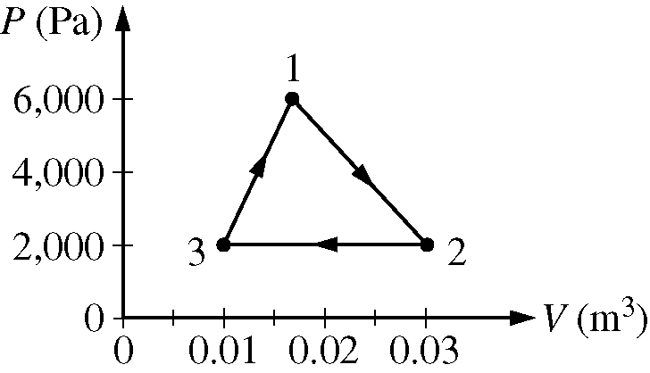

```python
display(Image(filename='./img/GR1777_28.png'))
```

### 28. A sample of nitrogen gas undergoes the cyclic thermodynamic process shown above. Which of the following gives the net heat transferred to the system in one complete cycle $1 \rightarrow 2 \rightarrow 3 \rightarrow 1$?

(A) $-80 J$

(B) $-40 J$

(C) $40 J$

(D) $80 J$

(E) $180 J$

- Total heat absorved = Total work done
- The work done is the area bounded by the curves
- $$ Q_{tot} = \frac{(6000 - 2000)(0.03 - 0.01)}{2} = 40 $$

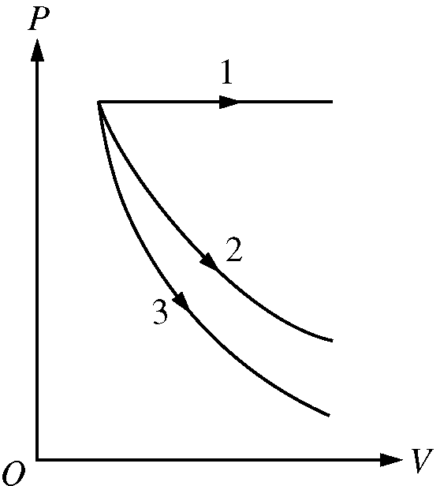

```python
display(Image(filename='./img/GR1777_29.png'))
```

### 29. For an ideal gas, consider the three thermodynamic processes —labeled 1, 2, and 3- shown in the PV diagram above. Each process has the same initial state and the same final volume. One process is adiabatic, one is isobaric, and one is isothermal. Which of the following correctly identifies the three processes?

(A) $1 \rightarrow Adiabatic$; $2 \rightarrow Isobaric$; $3 \rightarrow Isothermal$

(B) $2 \rightarrow Adiabatic$; $1 \rightarrow Isobaric$; $3 \rightarrow Isothermal$

(C) $2 \rightarrow Adiabatic$; $3 \rightarrow Isobaric$; $1 \rightarrow Isothermal$

(D) $3 \rightarrow Adiabatic$; $1 \rightarrow Isobaric$; $2 \rightarrow Isothermal$

(E) $3 \rightarrow Adiabatic$; $2 \rightarrow Isobaric$; $1 \rightarrow Isothermal$

- Adiabatic means that energy is transfered as work, none transfered as heat. Usually rapid processes that happen very fast have very little to no heat transfer.
- Isobaric means constant pressure
- Isothermal means constant temperature. The system usually evolves more slowly and stays in equilibrium with its environment
- (B) and (D) are the only answers with constant pressure. Because line 3 evolves faster then line 2, line 3 must be adiabatic

### 57. Which of the following statements is (are) true for a Maxwell-Boltzmann description of an ideal gas of atoms in equilibrium at temperature $T$?

### I. The average velocity of the atoms is zero.

### II. The distribution of the speeds of the atoms has a maximum at $v = 0$.

### III. The probability of finding an atom with zero kinetic energy is zero.

(A) I only

(B) II only

(C) I and II

(D) I and III

(E) II and III

- I. Yes, since they are all moving in different and opposite directions. Velocity has a directional component
- II. No, $v_p = (2 R T / M)^{1/2}$
- III. Yes, $F(E) = 1/e^{E/k T}$ and $E = (1/2) m v^2$ so would be 0 at $v = 0$

### 58. A monatomic ideal gas changes from an initial state ($P_i$, $V_i$, $T_i$, $ni$) to a final state ($P_f$, $V_f$, $T_f$, $n_f$), where $P_i < P_f$, $V_i = V_f$ , $T_i < T_f$ and $n_i = n_f$. Which of the following gives the change in entropy of the gas?

(A) $$ \frac{3}{2} n R ln \left(\frac{T_f}{T_i}\right) $$

(B) $$ \frac{3}{2} n R ln \left(\frac{T_i}{T_f}\right) $$

(C) $$ \frac{5}{2} n R ln \left(\frac{T_f}{T_i}\right) $$

(D) $$ \frac{5}{2} n R ln \left(\frac{T_i}{T_f}\right) $$

(E) $$ 0 $$

- Constant volume is isochoric $$ W = P \Delta V $$, but $$ \Delta V = 0 $$ $$ dU = dQ - P dV $$ $$ dU = dQ $$ $$ U = Q $$ $$ U = \frac{3}{2} N k $$, where $$ R = N k $$
- Entropy $$ \Delta S = \int C_V \frac{dT}{T} $$ $$ \Delta S = C_V ln\frac{T_f}{T_i} $$, where $$ C_V = \frac{3}{2} R $$ for a monochromatic gas

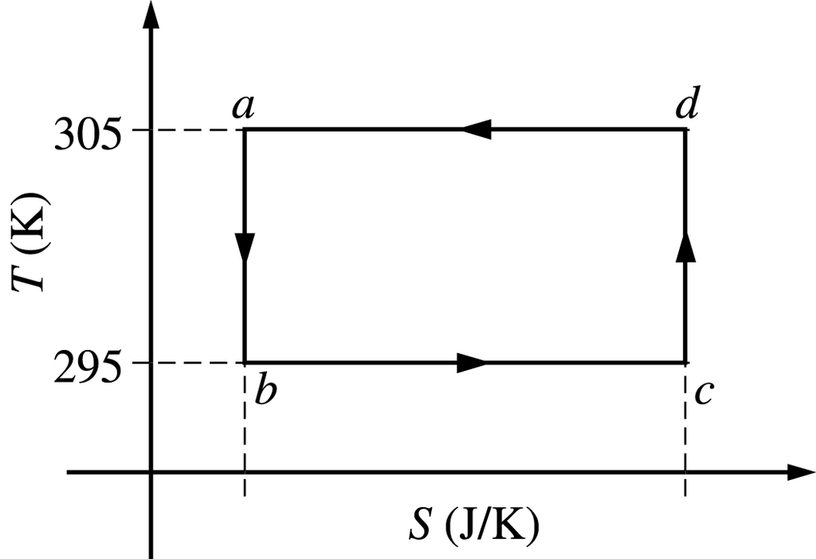

```python
display(Image(filename='./img/GR1777_91.png'))
```

### 91. The diagram above shows a Carnot cycle for an ideal air conditioner, which is to cool a house on a hot summer day. The air conditioner absorbs heat at the lower temperature inside and pumps it to the environment at the higher temperature outside. Which of the following gives the ratio of the heat $Q_{bc}$ absorbed in the house (i.e., between points $b$ and $c$ on the cycle) to the work done during the cycle?

(A) 0

(B) 0.033

(C) 0.97

(D) 1.0

(E) 30

- Carnot efficiency equation: $$ \frac{W}{Q_h} = 1 - \frac{T_c}{T_h} = 1 - \frac{295}{305} $$
- Inverse of the equation is $$ \frac{Q_h}{W} = \frac{305}{10} = 30.5 $$

## GR8677

### 14. For an ideal gas, the specific heat at constant pressure $C_p$ is greater than the specific heat at constant volume $C_v$ because the

(A) gas does work on its environment when its pressure remains constant while its temperature is increased

(B) heat input per degree increase in temperature is the same in processes for which either the pressure or the vilume is kept constant

(C) pressure of the gas remains constant when its temperature remains constant

(D) increase in the gas's internal energy is greater when the volume remains constant

(E) heat needed is greater when the volume remains constant than when the pressure remains constant

- The key equation is: $P V = n R T$, and its players, $P$, $V$, $n$, $R$, $T$, are terms one should be able to guess.
- (A) True, according to the ideal gas law. (This is also the final step in deriving Mayer’s Equation, as shown below.)
- (B) This translates into the statement $$ \left.\frac{dq}{dT}\right|_V = \left.\frac{dq}{dT}\right|_P \Rightarrow C_v = C_p $$. The problem gives away the fact that for an ideal gas $C_p \neq C_v$. B can’t be right.
- (C) According to the ideal gas law, the volume might change.
- (D) False. An ideal gas’s internal energy is dependent only on temperature. More elegantly, $u = u(T)$.
- (E) Heat needed for what? If one is interested in the formal proof of the relation $C_p = C_v + n R$, read on about Mayer’s equation: For thermo, in general, there’s an old slacker’s pride line that goes like, “When in doubt, write a bunch of equations of states and mindlessly begin taking exact differentials. Without exerting much brainpower, one will quickly arrive at a brilliant result.” Doing this, $$ Q = U + W \Rightarrow dQ = dU + P dV $$ $$ U = U(T, V) \Rightarrow dU = ∂_T U|_T + ∂_V U|_V $$ $$ P V = n R T \Rightarrow P dV + V dP = n R dT $$ Plugging in the first law of thermodynamics into the $U$ equation of state, one gets $$ dQ = ∂_T U|_T + (∂_T U|_V + P) dV = ∂_T U|_T +P dV $$, where the last simplification is made by remembering the fact that the internal energy of an ideal gas depends only on temperature. (Taking the derivative with respect to $T$ at constant volume, one gets $$ \left.\frac{dQ}{dT}\right|_V = ∂_T U|_T = C_v $$.) Plugging in the simplified result for dQ = ... into the third equation of state, the ideal gas equation, one gets: $$ dQ − C_v dT + V dP = n R dT $$. Taking the derivative at constant pressure, one gets: $$ \left.\frac{dQ}{dT}\right|_P = C_v + n R $$ So, one sees that it is the ideal gas equation that makes the final difference. The work of an ideal gas changes when temperature is varied.

### 15. A sample of $N$ atoms of helium gas is confined in a $1.0$ cubic meter volume. The probability that none of the helium atoms is in a $1.0 \times 10^{-6}$ cubic meter volume of the container is

(A) $0$

(B) $(10^{-6})^N$

(C) $(1 - 10^{-6})^N$

(D) $1 - (10^{-6})^N$

(E) $1$

- Probability is mostly common sense and adhering to definitions.
- The probability that a gas molecule or atom is in the small cube is $P(in) = 1 \times 10^{−6}$. The probability that it’s not in that small cube is $P(not) = 1 − 1 \times 10^{−6}$. Assuming independent gas molecules or atoms, i.e., the usual assumption of randomness in Stat Mech, one gets, $P(Ngasatoms) = (1 − 1 \times 10^{−6})^N$.
- The answer is thus C.

### 51. One feature common to both the Debye theory and the Einstein theory of the specific heat of a crystal composed of $N$ identical atoms is that the

(A) average energy of each atom is $3 k T$

(B) vibrational energy of the crystal is equivalent to the energy of $3 N$ independent harmonic oscillators

(C) crystal is assumed to be continuous for all elastic waves

(D) speed of the longitudinal elastic waves is less than the speed of the transverse elastic waves

(E) upper cutoff frequency of the elastic waves is the same

- Both Debye and Einstein assumed that there are $3N$ oscillators. (In fact, one can argue that the core of condensed matter begins with the assumption that a continuum piece of matter is basically a tiny mattress—a bunch of springs laden together.) Answer is thus (B).
- However, Einstein was too lazy, and he decided that all $3N$ oscillators have the same frequency. Debye assigned a spectrum of frequencies (phonons).

### 55. The mean kinetic energy of electrons in metals at room temperature is usually many times the thermal energy $k T$. Which of the following can best be used to explain this fact?

(A) The energy-time uncertainty relation

(B) The Pauli exclusion principle

(C) The degeneracy of the energy levels

(D) The Born approximation

(E) The wave-particle duality

### 66. For a system in which the number of particles is fixed, the reciprocal of the kelvin temperature $T$ is given by which of the following derivatives? (Let $P$ = pressure, $V$ = volume, $S$ = entropy, and $U$ = internal energy.)

(A) $$ \left(\frac{\partial P}{\partial V}\right)_S $$

(B) $$ \left(\frac{\partial P}{\partial S}\right)_V $$

(C) $$ \left(\frac{\partial S}{\partial P}\right)_U $$

(D) $$ \left(\frac{\partial V}{\partial P}\right)_U $$

(E) $$ \left(\frac{\partial S}{\partial U}\right)_V $$

- Recall that $dQ = T dS = P dV + dU$, where work done by the system is positive and heat input into the system is positive. For constant volume, the equation becomes $dQ = T dS = dU$, $$ \Rightarrow \frac{1}{T} = \left(\frac{\partial U}{\partial S}\right)_V $$

### 67. A large isolated system of $N$ weakly interacting particles is in thermal equilibrium. Each particle has only 3 possible nondegenerate states of energies $0$, $\varepsilon$, and $3 \varepsilon$. When the system is at an absolute temperature $T \gg \frac{\varepsilon}{k}$, where $k$ is Boltzmann's constant, the average energy of each particle is

(A) $0$

(B) $\varepsilon$

(C) $\frac{4}{3} \varepsilon$

(D) $2 \varepsilon$

(E) $3 \varepsilon$

- The problem gives three non-degenerate energies, so one can just directly plug this into the canonical(?) partition function to get, $$ Z = \sum_i e^{-\frac{\epsilon_i}{k T}} = 1 + e^{-\frac{\epsilon_i}{k T}} + e^{-3 \frac{\epsilon_i}{k T}} $$ where $k$ is the Boltzmann constant, $T$ is the (absolute) temperature.
- Since, $$ U = \frac{N k T^2}{Z} \frac{\partial Z}{\partial T} = N k^2 \left(\frac{\epsilon}{k T^2} e^{-\frac{\epsilon_i}{k T}} + \frac{3 \epsilon}{k T^2} e^{-3 \frac{\epsilon_i}{k T}}\right) $$
- For $\epsilon \gg k T$, one can expand $e^x \approx 1 + x$, and thus, $$ \frac{U}{n k^2} \approx \frac{\epsilon}{k T^2} \left(\frac{1 - \epsilon}{k T}\right) + \frac{3 \epsilon}{k T^2} \left(\frac{1 - 3 \epsilon}{k T}\right) \approx 4 \epsilon $$, where one throws out the higher order $\epsilon$ terms. ($Z \approx 1$ in denominator)
- The average energy of each particle is $$ \frac{U}{3} = \frac{4}{3} \epsilon $$, as in choice (C).

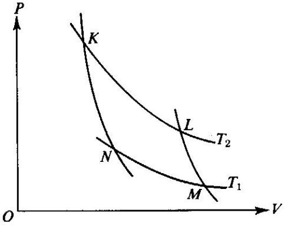

```python
display(Image(filename='./img/GR8677_95.png'))
```

### 95. In the cycke shown above, $KL$ and $NM$ represent isotherms, while $KN$ and $LM$ represent reversible adiabats. A system is carried through the Carnot cycle $KLMN$, taking in heat $Q_2$ from the hot reservoir $T_2$ and releasing heat $Q_1$ to the cold reservoir $T_1$. All of the following statememnts are true EXCEPT:

(A) $Q_1/T_1 = Q_2/T_2$

(B) The entropy of the hot reservoir decreases

(C) The entropy of the system increases

(D) The work $W$ done is equal to the net heat absorbed, $Q_2 - Q_1$

(E) The efficiency of the cycle is independent of the working substance

- The Carnot cycle is the cycle of the most efficient engine, which does NOT have $e = 1$ (unless $T_1 = 0$), but rather, $dS = 0$ — this means that entropy stays constant. Choice (C) is thus false.
- The efficiency of the Carnot cycle is dependent on the temperature of the hot and cold reservoir. The hot reservoir has decreasing entropy because it gets cooler as the cycle proceeds. From writing down the thermodynamic relations for isothermal and adiabatic paths and matching $P$-$V$ boundary conditions, one can determine that $Q_1/Q_2 = T_1/T_2$. The efficiency is thus $$ e = \frac{Q_2 - Q_1}{Q_2} = 1 − \frac{Q1}{Q2} = 1 − \frac{T_1}{T_2} $$

## GR9277

### 14. The total energy of a blackbody radiation source is collected for one minute and used to heat water. The temperature of the water increases from $20.0^{\circ}C$ to $20.5^{\circ}C$. If the absolute temperature of the blackbody is doubled and the experiment repeated, which of the following statements would be most nearly correct?

(A) The temperature of the water would increase from $20.0^{\circ}C$ to a final temperature of $21.0^{\circ}C$

(B) The temperature of the water would increase from $20.0^{\circ}C$ to a final temperature of $24.0^{\circ}C$

(C) The temperature of the water would increase from $20.0^{\circ}C$ to a final temperature of $28.0^{\circ}C$

(D) The temperature of the water would increase from $20.0^{\circ}C$ to a final temperature of $36.0^{\circ}C$

(E) The water would boil within the one-minute time period

- Recall $$ P = ut \propto T^4 $$, where $P$ is the power and $u$ the energy and $T$ the temperature.
- So, initially, the blackbody radiation emits $P_1 = k T^4$. When its temperature is doubled, it emits $P_2 = k(2T)^4 = 16k T^4$.
- Recall that water heats according to $Q = m c \Delta T = κ \Delta T$. So, initially, the heat gain in the water is $Q_1 = k(0.5^{\circ})$. Finally, $Q_2 = k x$, where $x$ is the unknown change in temperature.
- Conservation of energy in each step requires that $k T^4 t = k/2$ and $16k T^4 t = k x$, i.e., that $P_i t = Q_i$. Divide the two to get $\frac{1}{16} = \frac{2}{x} \Rightarrow x = \Delta T = 8^{\circ}$. Assuming the experiment is repeated from the same initial temperature, this would bring the initial $20^{\circ}$ to $28^{\circ}$, as in choice (C).

```python
display(Image(filename='./img/GR9277_15.png'))
```

[output not shown]

(A) $$ \frac{3}{2} R $$

(B) $$ \frac{5}{2} R $$

(C) $$ \frac{7}{2} R $$

(D) $$ \frac{9}{2} R $$

(E) $$ \frac{11}{2} R $$

- Note that this problem wants the regime of high temperatures, and thus the answer is not $\frac{5}{2} R$ from classical thermodynamics, but rather $\frac{7}{2} R$.
- The problem suggests that a quantized linear oscillator is used. From the energy relation $\epsilon = \left(j + \frac{1}{2}\right) h \nu$, one can write a partition function and do the usual Stat Mech jig. Since one is probably too lazy to calculate entropy, one can find the specific heat (at constant volume) from $C_V = \left.\frac{\partial U}{\partial T}\right|_V$, where $U = N k T^2 \left(\frac{\partial Z}{\partial T}\right)_V$, where $N$ is the number of particles, $k$ is the Boltzmann constant.
- There are actually three contributions to the specific heat at constant volume. $C_V = c_{translational} + c_{rotational} + c_{vibrational}$. Chunk out the math and take the limit of high temperature to find that $$ C_V = \frac{7}{2} R $$

### 16. An engine absorbs heat at a temperature of $727^{\circ}C$ and exhausts heat at a temperature of $527^{\circ}C$. If the engine operates at maximum possible efficiency, for $2000 joules$ of heat input the amount of work the engine performs is most nearly

(A) $400 J$

(B) $1450 J$

(C) $1600 J$

(D) $2000 J$

(E) $2760 J$

- Recall the common-sense definition of the efficiency e of an engine, $$ e = \frac{W_{accomplished}}{Q_{input}} $$ ,where one can deduce from the requirements of a Carnot process (i.e., two adiabats and two isotherms), that it simplifies to $$ e = 1 − \frac{T_{low}}{T_{high}} $$ for Carnot engines, i.e., engines of maximum possible efficiency. ($Q_{input}$ is heat put into the system to get stuff going, $W$ is work done by the system and $T_{low}$ ($T_{high}$) is the isotherm of the Carnot cycle at lower (higher) temperature.)
- The efficiency of the Carnot engine is thus $$ e = 1 − \frac{800}{1000} = 0.2 $$, where one needs to convert the given temperatures to Kelvin units. (As a general rule, most engines have efficiencies lower than this.) The heat input in the system is $$ Q_{input} = 2000J $$, and thus $$ W_{accomplished} = 400J $$, as in choice (A).

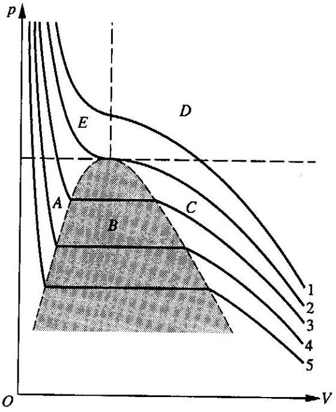

```python
display(Image(filename='./img/GR9277_46.png'))
```

### Isotherms and coexistence curves are shown in the $pV$ diagram above for a liquid-gas system. The dashed lines are the coundaries of the labeled regions.

### 46. Which numbered curve is the critical isotherm?

(A) 1

(B) 2

(C) 3

(D) 4

(E) 5

- The critical isotherm is the (constant temperature) line that just touches the critical liquid-vapor region, explained in the next question. The condition for the critical isotherm is $$ \left(\frac{dP}{dV}\right)_c = 0 $$ and $$ \left(\frac{d^2 P}{dV^2}\right)_c = 0 $$, where $c$ denotes the critical point.

### 47. In which region are the liquid and the vapor in equilibrium with each other?

(A) A

(B) B

(C) C

(D) D

(E) E

- The liquid-vapor region is where the substance can coexist as both a liquid and vapor. (A gas is just a vapor at normal temperatures.)
- In this region, the liquid and vapor are in equilibrium, hence their coexistence. Equilibrium occurs when $$ P_v = P_l $$ and $$ \mu_v = \mu_l $$ , i.e., when the pressure and chemical potential of the liquid and vapor are equal to each other.
- Since region B shows a constant pressure behavior, despite the volume-decrease, it is the region of liquid-vapor equilibrium.

### 62. A mole of ideal gas initially at temperature $T_0$ and volume $V_0$ undergoes a reversible isothermal expansion to volume $V_1$. If the ratio of specific heat is $C_P/C_V = \gamma$ and if $R$ is the gas constant, the work done by the gas is

(A) $$ zero $$

(B) $$ R T_0 \left(\frac{V_1}{V_0}\right)^\gamma $$

(C) $$ R T_0 \left(\frac{V_1}{V_0} - 1\right) $$

(D) $$ C_V T_0 \left[1 - \left(\frac{V_0}{V_1}\right)^{\gamma - 1} \right] $$

(E) $$ R T_0 ln \left(\frac{V_1}{V_0}\right) $$

- The work done by a gas in an isothermal expansion is related to the log of the volumes. If one forgets this, one can quickly derive it from recalling the definition of work $$ W = \int P dV $$ and the ideal gas law equation of state $$ P V = n R T \Rightarrow P = \frac{n R T}{V} $$.
- One has $$ W = \int n R T \frac{dV}{V} $$. For 1 mole, one has $n = 1$, which yields choice (E).
- (And the condition for isothermality $$ P_1 V_1 = P_0 V_0 = n R T_1 = n R T_0 $$ allows one to change the argument in the log.)

### 63. Which of the following is true if the arrangement of an isolated thermodynamic system is of maximal probability?

(A) Spontaneous change to a lower probability occurs

(B) The entropy is a miminum

(C) Boltzmann's constant approaches zero

(D) No spontaneous change occurs

(E) The entropy is zero

- According to statistical mechanics, maximal probability is the sate of highest entropy---it's the peak of a Gaussian curve, the average score on a normally-curved test.
- Spontaneous change to lower probability thus does not occur since maximal probability is the most stable state--one of highest entropy. Boltzmann's constant never approaches 0, however in the third law of thermodynamics, one has the entropy approaching 0 for $T \rightarrow 0$.
- Eliminating choices, one has choice (D).

### A system in thermal equilibrium at temperature $T$ consists of a large number $N_0$ of subsystems, each of which can exist only in two states of energy $E_1$ and $E_2$, where $E_2 - E_1 = \varepsilon > 0$. In the expressions that follow, $k$ is the Boltzmann constant.

### 71. For a system at temperature $T$, the average number of subsystems in the state of energy $E_1$ is given by

(A) $$ \frac{N_0}{2} $$

(B) $$ \frac{N_0}{1 + e^{-\frac{\varepsilon}{K T}}} $$

(C) $$ N_0 e^{-\frac{\varepsilon}{K T}} $$

(D) $$ \frac{N_0}{1 + e^{\frac{\varepsilon}{K T}}} $$

(E) $$ \frac{N_0 e^{\frac{\varepsilon}{K T}}}{2} $$

- The Fermi-Dirac distribution, in general, gives the number of states in $E_i$ to be $$ N_{FD} = N_0 \frac{1}{1 + e^{-\frac{E_i}{k T}}} $$, where $N_0$ is the total number of states. (The Fermi-Dirac distribution is used since there are only two states.)
- Define $E_1 = \varepsilon$ and $E_2 = 2 \varepsilon$.
- The number of states in 1 is just $$ N_1 = N_0\frac{1}{1 + e^{-\frac{E_1}{k T}}} = N_0\frac{1}{1 + e^{-\frac{\varepsilon}{k T}}} $$, which is choice (B).

### 72. The internal energy of this system at any temperature $T$ is given by $E_1 N_0 + \frac{N_0 \varepsilon}{1 + e^{\frac{\varepsilon}{k T}}}$. The heat capacity of the system is given by which of the following expressions?

(A) $$ N_0 k \left(\frac{\varepsilon}{k T}\right)^2 \frac{e^{\frac{\varepsilon}{k T}}}{\left(1 + e^{\frac{\varepsilon}{k T}}\right)^2} $$

(B) $$ N_0 k \left(\frac{\varepsilon}{k T}\right)^2 \frac{1}{\left(1 + e^{\frac{\varepsilon}{k T}}\right)^2} $$

(C) $$ N_0 k \left(\frac{\varepsilon}{k T}\right)^2 e^{\frac{\varepsilon}{k T}} $$

(D) $$ \frac{N_0 k}{2} \left(\frac{\varepsilon}{k T}\right)^2 $$

(E) $$ \frac{3}{2} N_0 k $$

- The heat capacity is just $$ \frac{dU}{dT} $$, where $ETS$ generously supplies $U$, the internal energy. Since $E_1$ and $N_0$ are constants, the first term is trivial.
- The temperature-derivative of the second term is $$ N_0 k \left(\frac{\varepsilon}{k T}\right)^2 \frac{e^{\frac{\varepsilon}{k T}}}{\left(1 + e^{\frac{\varepsilon}{k T}}\right)^2} $$, as in choice (A).
- The temperature derivative is easily done if one applies the chain-rule $$ \frac{df}{dy} \frac{dy}{du} \frac{du}{dT} $$ where $$ f = \frac{1}{y} $$ $$ y = 1 + e^u $$ $$ u = \frac{\varepsilon}{k T} $$

### 73. Which of the following is true of the entropy of the system?

(A) It increases without limit with $T$ from zero at $T = 0$

(B) It decreases with increasing $T$

(C) It increases from zero at $T = 0$ to $N_0 k ln(2)$ at arbitrarily high temperatures

(D) It is given by $$ N_0 k \left[\frac{5}{2} ln T - ln p + constant\right] $$

(E) It cannot be calculated from the information given

- The third law of thermodynamics says that $$ S(T \rightarrow 0) \rightarrow 0 $$.
- Also, the statistical definition of entropy is just $$ S = N k lnZ $$, where $Z$ is the partition function. For this problem, one has $$ Z = e^{-\frac{\epsilon}{k T}} + e^{-2 \frac{\epsilon}{k T}} $$. For high temperatures, one has $$ Z = 1 + 1 = 2 $$, since $e^x \approx 1 + x$ for small $x$ (and then $1 + x \approx 1$ for very small $x$).
- Thus the entropy behaves as in choice (C).

## GR9677

### 13. A 100-watt electric heating element is placed in a pan containing one liter of water. Although the heating element is on for a long time, the water, though close to boiling, does not boil. When the heating element is removed, approximately how long will it take to cool by $1^{\circ}C$? (Assume that the specific heat for water is $4.2 kJ/Kg ^{\circ}C$)

(A) 20s

(B) 40s

(C) 60s

(D) 130s

(E) 200s

- Given $P = 100 W$ and $V = 1L = 1m^3 = 1kg$ for water, one can chunk out the specific heat equation for heat, $$ Q = m c \Delta T = P t \Rightarrow 4200(1^{\circ}) = 100t ⇒ t ≈ 40s $$, as in choice (B).

### 14. Two identical 1.0 kilogram blocks of cooper metal, one initially at a temperature $T_1 = 0^{\circ}C$ and the other innitially at a temperature $T_2 = 100^{\circ}C$, are enclosed in a perfectly insulating container. The two blocks are initially separated. When the blocks are placed in contact, they come to equilibrium at a final temperature $T_f$. The amount of heat exchanged between the two blocks in this process is equal to which of the following? (The specific heat of cooper metal is equal to $0.1 kilocalorie/kilogram ^{\circ}K$)

(A) 50 kcal

(B) 25 kcal

(C) 10 kcal

(D) 5 kcal

(E) 1 kcal

- The final temperature is $50^{\circ}C$. The heat exchanged from the hot block to the cool block is $$ Q = m c \Delta T = 5 kcal $$, as in choice (D).

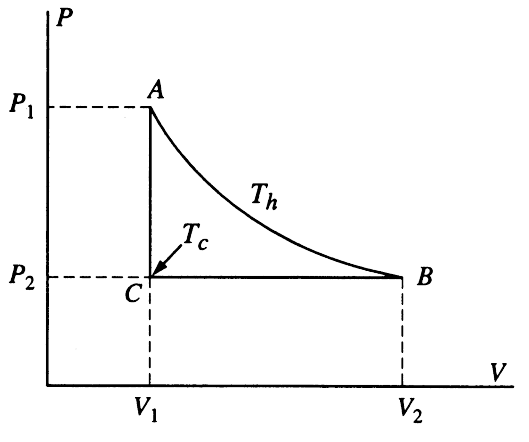

```python
display(Image(filename='./img/GR9677_15.png'))
```

### 15. Suppose one mole of an ideal gas undergoes the reversible cycle $ABCA$ shown in the $P-V$ diagram above, where $AB$ is an isotherm. The molar heat capacities are $C_P$ at constant pressure and $C_V$ at constant volume. The net heat added to the gas during the cycle is equal to

(A) $$ R T_h \frac{V_2}{V_1} $$

(B) $$ -C_P (T_h - T_c) $$

(C) $$ C_V (T_h - T_c) $$

(D) $$ R T_h ln \frac{V_2}{V_1} - C_P(T_h - T_c) $$

(E) $$ R T_h ln \frac{V_2}{V_1} - R(T_h - T_c) $$

- Recall that for an ideal gas $U = C_v \Delta T$ and $P V = n R T$. Don’t forget the first law of thermodynamics, $Q = W + U$.
- For $A \rightarrow B$, $U = 0$, since the temperature is constant. Thus, $$ Q = W = R T_h ln \frac{V_2}{V_1} $$.
- For $B \rightarrow C$, $W = P_2(V_1 − V_2) = R(T_c − T_h)$. $U = C_v(T_c − T_h)$, and thus $$ Q = W + U = C_v(T_c − T_h) − R(T_h − T_c) $$.
- For $C \rightarrow A$, $W = 0$, $U = C_v(T_h − T_c)$, thus $$ Q = U = C_v(T_h − T_c) $$
- Add up all the $Q$’s from above, cancel the $C_v$ term, to get $$ Q_{tot} = R T_h ln \frac{V2}{V1} − R(T_h − T_c) $$, as in choice (E).

### 73. The adiabatic expansion of an ideal gas is described by the equation $$ P V^{\gamma} = C $$, where $\gamma$ and $C$ are constants. The work done by the gas in expanding adiabatically from the state $(V_i, P_i)$ to $(V_f, P_f)$ is equal to

(A) $$ P_f V_f $$

(B) $$ \frac{P_i + P_f}{2} (V_f - V_i) $$

(C) $$ \frac{P_f V_f - P_i V_i}{1 - \gamma} $$

(D) $$ \frac{P_i \left({V_f}^{1 + \gamma} - {V_i}^{1 + \gamma}\right)}{1 + \gamma} $$

(E) $$ \frac{P_f \left({V_f}^{1 + \gamma} - {V_i}^{1 + \gamma}\right)}{1 + \gamma} $$

- One should recall the expression for work done by an ideal gas in an adiabatic process. But, if not, one can easily derive it from the condition given in the problem, viz., $$ P V^{\gamma} = C \Rightarrow P = \frac{C}{V^{\gamma}} $$
- Recall that the definition of work is $$ W = \int P dV = \int_{V_1}^{V_2} C \frac{dV}{V^{\gamma}} = \left.−\frac{1}{\gamma − 1} \frac{C}{V^{\gamma − 1}}\right|_{V_1}^{V_2} $$, which when one plugs in the endpoint limits, becomes choice (C).

### 74. A body of mass $m$ with specific heat $C$ at temperature $500 K$ is brought into contact with an identical body at temperature $100 K$, and the two are isolated from their surroundings. The change in entropy of the system is equal to

(A) $\frac{4}{3} m C$

(B) $m C ln\frac{9}{5}$

(C) $m C ln3$

(D) $-m C ln\frac{5}{3}$

(E) $0$

- Recall the definition of entropy to be $$ dS = \frac{dQ}{T} $$. The heat is defined here as $$ dQ = m c dT $$, and thus $$ S = \int m c \frac{dT}{T} $$
- One is given two bodies of the same mass. One mass is at $T_1 = 500$ and the other is at $T_2 = 100$ before they’re placed next to each other. When they’re put next to each other, one has the net heat transferred being 0, thus $$ Q_1 = −Q_2 \Rightarrow T_f = \frac{(T_1 + T_2)}{2} = 300 $$
- The entropy is thus $$ S = \int_{T_1}^{T_f} m c \frac{dT}{T} + \int_{T_2}^{T_f} m c \frac{dT}{T} = m c (ln \frac{3}{5} + ln 3) = 2 m c ln 3 − m c ln 5 = m c(ln 9 − ln 5) = mc ln \frac{9}{5} $$, as in choice (B).

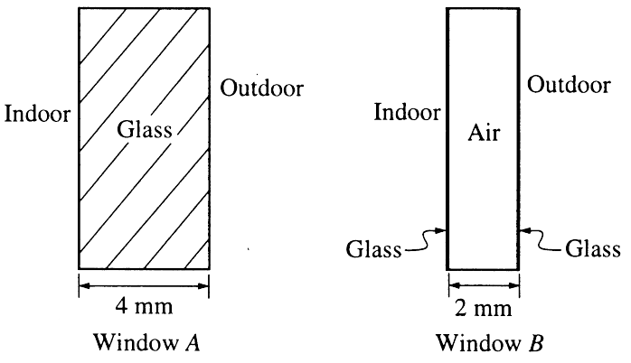

```python
display(Image(filename='./img/GR9677_75.png'))
```

### 75. Window A is a pane of glass 4 millimeters thick, as shown above. Window B is a sandwich consisting of two extremely thin layers of glass separated by an ir gas 2 millimeters thick, as shown above. If the Thermal conductivity of glass and air are $0.8 watt/meter ^{\circ}C$ and $0.025 watt/meter ^{\circ}C$, respectively, then the ratio of heat flow through window A to the heat flow through window B is

(A) 2

(B) 4

(C) 8

(D) 16

(E) 32

- Recall Fourier’s Law $$ q = −k \nabla T $$, where $q$ is the heat flux vector (rate of heat flowing through a unit area) and $T$ is the temperature and k is the thermal conductivity. (One can also derive it from dimensional analysis, knowing that the energy flux has dimensions of $J/(sm^2)$)
- Fourier’s Law implies the following simplification: $$ q = −k \frac{\Delta Tl}{\Delta l} $$
- The problem wants the ratio of heat flows $$ \frac{q_A}{q_B} = \frac{k_A l_B}{k_B l_A} = \frac{0.8 \times 2}{0.025 \times 4} = 16 $$, as in choice (D). (The problem gives $l_A = 4$, $l_B = 2$, and $k_A = 0.8$, $k_B = 0.025$.)

### 79. For an ideal diatomic gas in thermal equilibrium, the ratio of the molar heat capacity at constant volume at very high temperatures to that at very low temperatures is equal to

(A) 1

(B) 5/3

(C) 2

(D) 7/3

(E) 3

- The specific heat at constant volume for high temperatures is $$ C_v = \frac{7}{2} R$$. The specific heat at low temperatures is $$ \frac{3}{2} R $$. Why?
- There are three contributions to the specific heat of a diatomic gas. There is the translational, vibrational, and rotational. At low temperatures, only the translational heat capacity contributes $$ U = \frac{3}{2} Nk T \approx C_v T \Rightarrow C_v = \frac{3}{2} Nk $$. At high temperatures, all three components contribute, and one has $$ C_v = \left(\frac{3}{2} + 1 + 1 \right) Nk = \frac{7}{2} Nk $$
- The general formula is $$ C_v = {C_v}_{(translational)} + {C_v}_{(rotational)} + {C_v}_{(vibrational)} = \frac{Nk \left( \frac{3}{2} + 1 + \left(\frac{h \nu}{k \theta}\right) \right)^2 e^{\frac{h \nu}{k \theta}}}{e^{\frac{h \nu}{k \theta}} - 1} $$

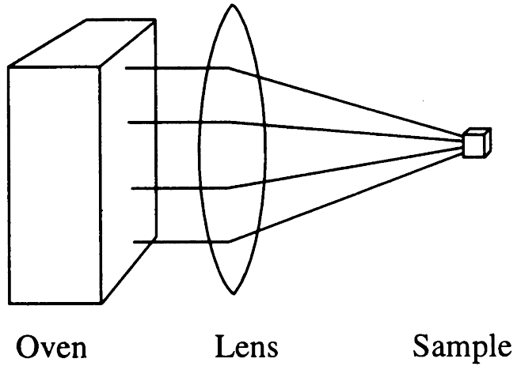

```python
display(Image(filename='./img/GR9677_91.png'))
```

### 91. An experimenter needs to heat a small sample to $900 K$, but the only available oven has a maximum temperature of $600 K$. Could the experimenter heat the sample to $900 K$ by using a large lens to concentrate the radiation from the oven onto the sample, as shown above?

(A) Yes, of the volume of the oven is at least 3/2 the volume of the sample

(B) Yes, if the area of the front of the oven is at least 3/2 the area of the front os the sample

(C) Yes, if the sample is placed at the focal point of the lens

(D) No, because it wuld violate conservation of energy

(E) No, because it would violate the second law of thermodynamics

- The Second Law of thermodynamics has to do with entropy; that entropy can never decrease in the universe. One form of it states that from hot to cold things flow. A cooler body can thus never heat a hotter body. Since the oven is at a much lower temperature than the wanted sample temperature, the oven can only heat the sample to a maximum of $600 K$ without violating the Second Law. (This solution is due to David Latchman.)